# IABE Data Science Certificate - Module 1

### Code postal (preneur)

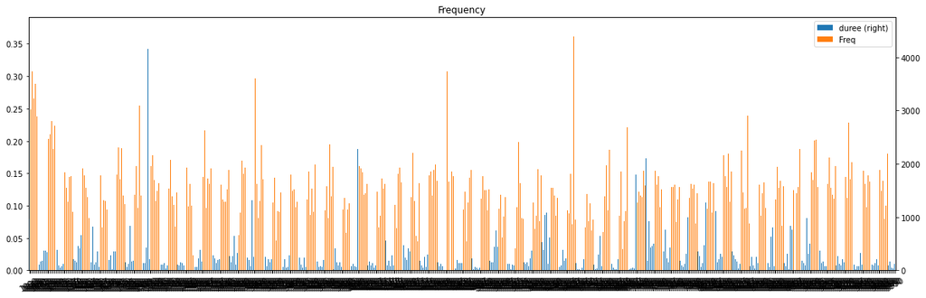

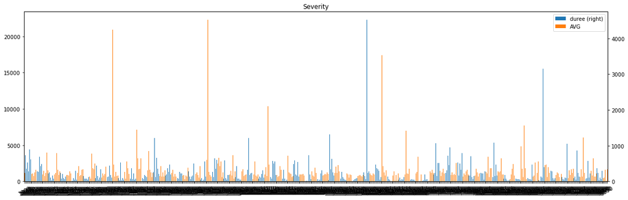

|  | CODPOSS | nbrtotc | duree | chargtot | Freq | AVG |
| --- | --- | --- | --- | --- | --- | --- |
| 0 | 1000 | 235 | 970.717808 | 278886.561444 | 0.242089 | 1186.751325 |
| 1 | 1030 | 184 | 738.339726 | 262239.420523 | 0.249208 | 1425.214242 |
| 2 | 1040 | 110 | 357.290411 | 196518.236287 | 0.307873 | 1786.529421 |
| 3 | 1050 | 139 | 524.616438 | 173932.235826 | 0.264955 | 1251.311049 |
| 4 | 1060 | 81 | 280.945205 | 73977.228500 | 0.288312 | 913.299117 |
| ... | ... | ... | ... | ... | ... | ... |
| 578 | 9950 | 13 | 97.298630 | 5826.216723 | 0.133609 | 448.170517 |
| 579 | 9960 | 19 | 167.405479 | 9603.692622 | 0.113497 | 505.457506 |
| 580 | 9970 | 5 | 43.312329 | 7917.223394 | 0.115441 | 1583.444679 |
| 581 | 9980 | 2 | 34.021918 | 135.399443 | 0.058786 | 67.699722 |
| 582 | 9990 | 21 | 126.049315 | 35087.419652 | 0.166601 | 1670.829507 |

583 rows × 6 columns

```python
description_analysis2("CODPOSS",my_data)
```

Regroupons les codes postaux par provinces:

```python
my_data["CODPOSS1"] = np.where(my_data['CODPOSS']<1299, "A.Bruxelles-Capitale",
np.where(my_data['CODPOSS']<1499, "B.Brabant wallon",
np.where(my_data['CODPOSS']<1999, "C.Brabant flamand",\
np.where(my_data['CODPOSS']<2999, "D.Anvers" ,
np.where(my_data['CODPOSS']<3499, "C.Brabant flamand",
np.where(my_data['CODPOSS']<3999, "E.Limbourg",
np.where(my_data['CODPOSS']<4999, "F.Liège" ,
np.where(my_data['CODPOSS']<5680, "G.Namur" ,
np.where(my_data['CODPOSS']<6599, "H.Hainaut" ,
np.where(my_data['CODPOSS']<6999, "I.Luxembourg" ,
np.where(my_data['CODPOSS']<7999, "H.Hainaut" ,
np.where(my_data['CODPOSS']<8999, "J.Flandre-Occidentale", "K.Flandre-Orientale"))))))))))))
```

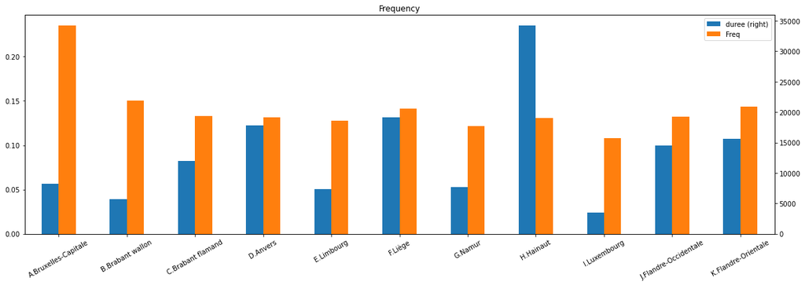

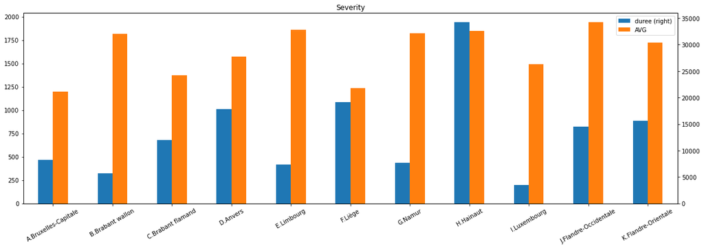

|  | CODPOSS1 | nbrtotc | duree | chargtot | Freq | AVG |
| --- | --- | --- | --- | --- | --- | --- |
| 0 | A.Bruxelles-Capitale | 1925 | 8188.019178 | 2.300166e+06 | 0.235100 | 1194.891384 |
| 1 | B.Brabant wallon | 854 | 5684.909589 | 1.551399e+06 | 0.150222 | 1816.627000 |
| 2 | C.Brabant flamand | 1597 | 11989.178082 | 2.189970e+06 | 0.133203 | 1371.302228 |
| 3 | D.Anvers | 2330 | 17771.123288 | 3.667861e+06 | 0.131112 | 1574.189196 |
| 4 | E.Limbourg | 935 | 7315.150685 | 1.736757e+06 | 0.127817 | 1857.493807 |
| 5 | F.Liège | 2705 | 19135.750685 | 3.340034e+06 | 0.141358 | 1234.763045 |
| 6 | G.Namur | 938 | 7718.271233 | 1.707709e+06 | 0.121530 | 1820.585492 |
| 7 | H.Hainaut | 4481 | 34231.956164 | 8.288378e+06 | 0.130901 | 1849.671426 |
| 8 | I.Luxembourg | 379 | 3511.690411 | 5.660582e+05 | 0.107925 | 1493.557375 |
| 9 | J.Flandre-Occidentale | 1918 | 14512.367123 | 3.724288e+06 | 0.132163 | 1941.756015 |
| 10 | K.Flandre-Orientale | 2228 | 15561.312329 | 3.838862e+06 | 0.143176 | 1723.008088 |

```python
description_analysis2("CODPOSS1",my_data)
```

**Constatations:**

- La fréquence sinistres est beaucoup plus importante à Bruxelles

# Training & Test sets

Avant de modéliser la fréquence sinistre et le coût moyen, nous allons diviser notre DB en training set (80% de la DB initiale) et test set (20% de la DB initiale).

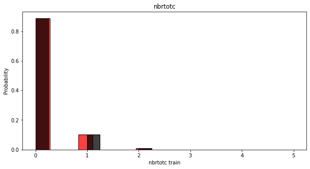

```python
np.random.seed(123)

my_data_X = my_data.drop(labels=['nbrtotc'], axis=1)
my_data_X_train, my_data_X_test, my_data_y_train, my_data_y_test = train_test_split(my_data_X,my_data.nbrtotc, test_size=0.2, stratify=my_data.nbrtotc)


my_data_train=my_data_X_train
my_data_train["nbrtotc"]=my_data_y_train

my_data_test=my_data_X_test
my_data_test["nbrtotc"]=my_data_y_test


df = pd.DataFrame(my_data_y_train)
df1 = pd.DataFrame(my_data_y_test)

plot_pd = pd.concat([df,df1], ignore_index=True, axis=1)

#rename columns for x-label
plot_pd.columns = ['nbrtotc train', 'nbrtotc test']

#plot

fig, axs = plt.subplots(ncols=1, figsize=(10,5));
sb.histplot(plot_pd ['nbrtotc train'], ax = axs, color='r',stat="probability").set(title='nbrtotc');
sb.histplot(plot_pd['nbrtotc test'], ax = axs, color='k',stat="probability");
plt.show()
```

# GLM Frequency

Nous allons modéliser la fréquence sinistres par un GLM (loi de Poisson) sur le training set.

Créons d'abord un premier modèle avec toutes les variables:

```python
freq_glm_tot = smf.glm('nbrtotc ~ coverp + powerc1 + AGEPH3 + sexp  + agecar + fuelc + split1 + usec + fleetc + sportc+ CODPOSS1',
                data = my_data_train, exposure = my_data_train.duree,
                family = sm.families.Poisson(link=sm.families.links.log())).fit()

print(freq_glm_tot.summary())
```

```
                 Generalized Linear Model Regression Results
==============================================================================
Dep. Variable:                nbrtotc   No. Observations:               130925
Model:                            GLM   Df Residuals:                   130897
Model Family:                 Poisson   Df Model:                           27
Link Function:                    log   Scale:                          1.0000
Method:                          IRLS   Log-Likelihood:                -50210.
Date:                Wed, 12 Jan 2022   Deviance:                       70152.
Time:                        19:12:36   Pearson chi2:                 1.52e+05
No. Iterations:                     6
Covariance Type:            nonrobust
=====================================================================================================
                                        coef    std err          z      P>|z|      [0.025      0.975]
-----------------------------------------------------------------------------------------------------
Intercept                            -0.2984      0.106     -2.825      0.005      -0.505      -0.091
coverp[T.MTPL+]                      -0.1346      0.020     -6.815      0.000      -0.173      -0.096
coverp[T.MTPL+++]                    -0.1539      0.028     -5.565      0.000      -0.208      -0.100
powerc1[T.B.>66]                      0.0996      0.019      5.323      0.000       0.063       0.136
AGEPH3[T.B.21-30]                    -0.5198      0.095     -5.475      0.000      -0.706      -0.334
AGEPH3[T.C.31-50]                    -0.9031      0.094     -9.575      0.000      -1.088      -0.718
AGEPH3[T.D.>50]                      -1.0923      0.095    -11.523      0.000      -1.278      -0.907
sexp[T.Male]                         -0.0341      0.018     -1.887      0.059      -0.069       0.001
agecar[T.2-5]                        -0.2573      0.037     -7.026      0.000      -0.329      -0.186
agecar[T.6-10]                       -0.1944      0.037     -5.205      0.000      -0.268      -0.121
agecar[T.>10]                        -0.2011      0.040     -5.049      0.000      -0.279      -0.123
fuelc[T.Petrol]                      -0.1912      0.017    -11.099      0.000      -0.225      -0.157
split1[T.B.Twice]                     0.1920      0.020      9.776      0.000       0.154       0.230
split1[T.C.Trice]                     0.4042      0.028     14.503      0.000       0.350       0.459
split1[T.D.Monthly]                   0.3041      0.025     12.330      0.000       0.256       0.352
usec[T.Professional]                  0.0102      0.037      0.275      0.784      -0.063       0.083
fleetc[T.Yes]                        -0.1269      0.049     -2.609      0.009      -0.222      -0.032
sportc[T.Yes]                         0.1048      0.077      1.370      0.171      -0.045       0.255
CODPOSS1[T.B.Brabant wallon]         -0.4245      0.045     -9.359      0.000      -0.513      -0.336
CODPOSS1[T.C.Brabant flamand]        -0.5409      0.038    -14.239      0.000      -0.615      -0.466
CODPOSS1[T.D.Anvers]                 -0.5399      0.035    -15.516      0.000      -0.608      -0.472
CODPOSS1[T.E.Limbourg]               -0.6387      0.045    -14.096      0.000      -0.727      -0.550
CODPOSS1[T.F.Liège]                  -0.5030      0.034    -14.847      0.000      -0.569      -0.437
CODPOSS1[T.G.Namur]                  -0.6693      0.045    -14.914      0.000      -0.757      -0.581
CODPOSS1[T.H.Hainaut]                -0.5711      0.031    -18.271      0.000      -0.632      -0.510
CODPOSS1[T.I.Luxembourg]             -0.8176      0.063    -12.899      0.000      -0.942      -0.693
CODPOSS1[T.J.Flandre-Occidentale]    -0.6376      0.038    -16.951      0.000      -0.711      -0.564
CODPOSS1[T.K.Flandre-Orientale]      -0.4824      0.036    -13.481      0.000      -0.553      -0.412
=====================================================================================================
```

Changeons les niveaux de réference:

```python
freq_glm_tot_ref = smf.glm('nbrtotc ~ C(coverp,Treatment(reference="MTPL"))+C(powerc1,Treatment(reference="A.<66")) + C(AGEPH3, Treatment(reference="C.31-50"))+ C(sexp, Treatment(reference="Male"))+ C(agecar, Treatment(reference="6-10"))  + C(fuelc, Treatment(reference="Gasoil")) + C(split1, Treatment(reference="A.Once")) + C(usec, Treatment(reference="Private")) + C(fleetc, Treatment(reference="No")) + C(sportc, Treatment(reference = "No"))+C(CODPOSS1, Treatment(reference="H.Hainaut"))' , data = my_data_train, exposure = my_data_train.duree,  family = sm.families.Poisson(link=sm.families.links.log())).fit()

print(freq_glm_tot_ref.summary())
```

```
                 Generalized Linear Model Regression Results
==============================================================================
Dep. Variable:                nbrtotc   No. Observations:               130925
Model:                            GLM   Df Residuals:                   130897
Model Family:                 Poisson   Df Model:                           27
Link Function:                    log   Scale:                          1.0000
Method:                          IRLS   Log-Likelihood:                -50210.
Date:                Wed, 12 Jan 2022   Deviance:                       70152.
Time:                        19:12:51   Pearson chi2:                 1.52e+05
No. Iterations:                     6
Covariance Type:            nonrobust
==========================================================================================================================================
                                                                             coef    std err          z      P>|z|      [0.025      0.975]
------------------------------------------------------------------------------------------------------------------------------------------
Intercept                                                                 -2.0010      0.028    -71.574      0.000      -2.056      -1.946
C(coverp, Treatment(reference="MTPL"))[T.MTPL+]                           -0.1346      0.020     -6.815      0.000      -0.173      -0.096
C(coverp, Treatment(reference="MTPL"))[T.MTPL+++]                         -0.1539      0.028     -5.565      0.000      -0.208      -0.100
C(powerc1, Treatment(reference="A.<66"))[T.B.>66]                          0.0996      0.019      5.323      0.000       0.063       0.136
C(AGEPH3, Treatment(reference="C.31-50"))[T.A.18-20]                       0.9031      0.094      9.575      0.000       0.718       1.088
C(AGEPH3, Treatment(reference="C.31-50"))[T.B.21-30]                       0.3833      0.021     18.322      0.000       0.342       0.424
C(AGEPH3, Treatment(reference="C.31-50"))[T.D.>50]                        -0.1892      0.019    -10.098      0.000      -0.226      -0.152
C(sexp, Treatment(reference="Male"))[T.Female]                             0.0341      0.018      1.887      0.059      -0.001       0.069
C(agecar, Treatment(reference="6-10"))[T.0-1]                              0.1944      0.037      5.205      0.000       0.121       0.268
C(agecar, Treatment(reference="6-10"))[T.2-5]                             -0.0629      0.020     -3.111      0.002      -0.102      -0.023
C(agecar, Treatment(reference="6-10"))[T.>10]                             -0.0067      0.021     -0.320      0.749      -0.048       0.034
C(fuelc, Treatment(reference="Gasoil"))[T.Petrol]                         -0.1912      0.017    -11.099      0.000      -0.225      -0.157
C(split1, Treatment(reference="A.Once"))[T.B.Twice]                        0.1920      0.020      9.776      0.000       0.154       0.230
C(split1, Treatment(reference="A.Once"))[T.C.Trice]                        0.4042      0.028     14.503      0.000       0.350       0.459
C(split1, Treatment(reference="A.Once"))[T.D.Monthly]                      0.3041      0.025     12.330      0.000       0.256       0.352
C(usec, Treatment(reference="Private"))[T.Professional]                    0.0102      0.037      0.275      0.784      -0.063       0.083
C(fleetc, Treatment(reference="No"))[T.Yes]                               -0.1269      0.049     -2.609      0.009      -0.222      -0.032
C(sportc, Treatment(reference="No"))[T.Yes]                                0.1048      0.077      1.370      0.171      -0.045       0.255
C(CODPOSS1, Treatment(reference="H.Hainaut"))[T.A.Bruxelles-Capitale]      0.5711      0.031     18.271      0.000       0.510       0.632
C(CODPOSS1, Treatment(reference="H.Hainaut"))[T.B.Brabant wallon]          0.1466      0.041      3.541      0.000       0.065       0.228
C(CODPOSS1, Treatment(reference="H.Hainaut"))[T.C.Brabant flamand]         0.0301      0.033      0.907      0.365      -0.035       0.095
C(CODPOSS1, Treatment(reference="H.Hainaut"))[T.D.Anvers]                  0.0312      0.030      1.058      0.290      -0.027       0.089
C(CODPOSS1, Treatment(reference="H.Hainaut"))[T.E.Limbourg]               -0.0676      0.041     -1.655      0.098      -0.148       0.012
C(CODPOSS1, Treatment(reference="H.Hainaut"))[T.F.Liège]                   0.0681      0.027      2.494      0.013       0.015       0.122
C(CODPOSS1, Treatment(reference="H.Hainaut"))[T.G.Namur]                  -0.0982      0.040     -2.450      0.014      -0.177      -0.020
C(CODPOSS1, Treatment(reference="H.Hainaut"))[T.I.Luxembourg]             -0.2465      0.060     -4.101      0.000      -0.364      -0.129
C(CODPOSS1, Treatment(reference="H.Hainaut"))[T.J.Flandre-Occidentale]    -0.0665      0.032     -2.071      0.038      -0.129      -0.004
C(CODPOSS1, Treatment(reference="H.Hainaut"))[T.K.Flandre-Orientale]       0.0887      0.030      2.951      0.003       0.030       0.148
==========================================================================================================================================
```

Remplacons les variables AGEPH3 et sexp par leur interaction (comme vu plus haut):

```python
freq_glm_tot_ref_int = smf.glm('nbrtotc ~ C(coverp,Treatment(reference="MTPL"))+C(powerc1,Treatment(reference="A.<66")) + C(AGEPH3, Treatment(reference="C.31-50")):C(sexp, Treatment(reference="Male"))+ C(agecar, Treatment(reference="6-10"))  + C(fuelc, Treatment(reference="Gasoil")) + C(split1, Treatment(reference="A.Once")) + C(usec, Treatment(reference="Private")) + C(fleetc, Treatment(reference="No")) + C(sportc, Treatment(reference = "No"))+ C(CODPOSS1, Treatment(reference="H.Hainaut"))' , data = my_data_train, exposure = my_data_train.duree,  family = sm.families.Poisson(link=sm.families.links.log())).fit()

print(freq_glm_tot_ref_int.summary())
```

```
                 Generalized Linear Model Regression Results
==============================================================================
Dep. Variable:                nbrtotc   No. Observations:               130925
Model:                            GLM   Df Residuals:                   130894
Model Family:                 Poisson   Df Model:                           30
Link Function:                    log   Scale:                          1.0000
Method:                          IRLS   Log-Likelihood:                -50183.
Date:                Wed, 12 Jan 2022   Deviance:                       70099.
Time:                        19:13:17   Pearson chi2:                 1.52e+05
No. Iterations:                     6
Covariance Type:            nonrobust
=====================================================================================================================================================================
                                                                                                        coef    std err          z      P>|z|      [0.025      0.975]
---------------------------------------------------------------------------------------------------------------------------------------------------------------------
Intercept                                                                                            -2.0189      0.028    -70.889      0.000      -2.075      -1.963
C(coverp, Treatment(reference="MTPL"))[T.MTPL+]                                                      -0.1352      0.020     -6.844      0.000      -0.174      -0.096
C(coverp, Treatment(reference="MTPL"))[T.MTPL+++]                                                    -0.1534      0.028     -5.548      0.000      -0.208      -0.099
C(powerc1, Treatment(reference="A.<66"))[T.B.>66]                                                     0.0971      0.019      5.187      0.000       0.060       0.134
C(agecar, Treatment(reference="6-10"))[T.0-1]                                                         0.1942      0.037      5.198      0.000       0.121       0.267
C(agecar, Treatment(reference="6-10"))[T.2-5]                                                        -0.0633      0.020     -3.132      0.002      -0.103      -0.024
C(agecar, Treatment(reference="6-10"))[T.>10]                                                        -0.0082      0.021     -0.390      0.696      -0.049       0.033
C(fuelc, Treatment(reference="Gasoil"))[T.Petrol]                                                    -0.1905      0.017    -11.050      0.000      -0.224      -0.157
C(split1, Treatment(reference="A.Once"))[T.B.Twice]                                                   0.1899      0.020      9.671      0.000       0.151       0.228
C(split1, Treatment(reference="A.Once"))[T.C.Trice]                                                   0.3984      0.028     14.286      0.000       0.344       0.453
C(split1, Treatment(reference="A.Once"))[T.D.Monthly]                                                 0.3022      0.025     12.251      0.000       0.254       0.350
C(usec, Treatment(reference="Private"))[T.Professional]                                               0.0155      0.037      0.415      0.678      -0.058       0.089
C(fleetc, Treatment(reference="No"))[T.Yes]                                                          -0.1259      0.049     -2.588      0.010      -0.221      -0.031
C(sportc, Treatment(reference="No"))[T.Yes]                                                           0.0891      0.077      1.164      0.244      -0.061       0.239
C(CODPOSS1, Treatment(reference="H.Hainaut"))[T.A.Bruxelles-Capitale]                                 0.5701      0.031     18.237      0.000       0.509       0.631
C(CODPOSS1, Treatment(reference="H.Hainaut"))[T.B.Brabant wallon]                                     0.1475      0.041      3.561      0.000       0.066       0.229
```

[output cut: 16 more lines]

```python
freq_glm_tot_ref_int0 = smf.glm('nbrtotc ~ C(coverp,Treatment(reference="MTPL"))+C(powerc1,Treatment(reference="A.<66")) + C(AGEPH3, Treatment(reference="C.31-50")):C(sexp, Treatment(reference="Male"))+ C(agecar, Treatment(reference="6-10"))  + C(fuelc, Treatment(reference="Gasoil")) + C(split1, Treatment(reference="A.Once")) + C(usec, Treatment(reference="Private")) + C(fleetc, Treatment(reference="No")) + C(sportc, Treatment(reference = "No"))' , data = my_data_train, exposure = my_data_train.duree,  family = sm.families.Poisson(link=sm.families.links.log())).fit()

print(freq_glm_tot_ref_int0.summary())
```

```
                 Generalized Linear Model Regression Results
==============================================================================
Dep. Variable:                nbrtotc   No. Observations:               130925
Model:                            GLM   Df Residuals:                   130904
Model Family:                 Poisson   Df Model:                           20
Link Function:                    log   Scale:                          1.0000
Method:                          IRLS   Log-Likelihood:                -50401.
Date:                Wed, 12 Jan 2022   Deviance:                       70535.
Time:                        19:13:46   Pearson chi2:                 1.53e+05
No. Iterations:                     6
Covariance Type:            nonrobust
=====================================================================================================================================================================
                                                                                                        coef    std err          z      P>|z|      [0.025      0.975]
---------------------------------------------------------------------------------------------------------------------------------------------------------------------
Intercept                                                                                            -2.0062      0.023    -87.560      0.000      -2.051      -1.961
C(coverp, Treatment(reference="MTPL"))[T.MTPL+]                                                      -0.1070      0.019     -5.567      0.000      -0.145      -0.069
C(coverp, Treatment(reference="MTPL"))[T.MTPL+++]                                                    -0.1239      0.027     -4.522      0.000      -0.178      -0.070
C(powerc1, Treatment(reference="A.<66"))[T.B.>66]                                                     0.0998      0.019      5.345      0.000       0.063       0.136
C(agecar, Treatment(reference="6-10"))[T.0-1]                                                         0.1802      0.037      4.827      0.000       0.107       0.253
C(agecar, Treatment(reference="6-10"))[T.2-5]                                                        -0.0735      0.020     -3.640      0.000      -0.113      -0.034
C(agecar, Treatment(reference="6-10"))[T.>10]                                                         0.0021      0.021      0.101      0.920      -0.039       0.043
C(fuelc, Treatment(reference="Gasoil"))[T.Petrol]                                                    -0.1663      0.017     -9.686      0.000      -0.200      -0.133
C(split1, Treatment(reference="A.Once"))[T.B.Twice]                                                   0.1824      0.019      9.684      0.000       0.145       0.219
C(split1, Treatment(reference="A.Once"))[T.C.Trice]                                                   0.4111      0.027     15.167      0.000       0.358       0.464
C(split1, Treatment(reference="A.Once"))[T.D.Monthly]                                                 0.3833      0.024     15.962      0.000       0.336       0.430
C(usec, Treatment(reference="Private"))[T.Professional]                                               0.0231      0.037      0.619      0.536      -0.050       0.096
C(fleetc, Treatment(reference="No"))[T.Yes]                                                          -0.0899      0.049     -1.851      0.064      -0.185       0.005
C(sportc, Treatment(reference="No"))[T.Yes]                                                           0.0672      0.077      0.878      0.380      -0.083       0.217
C(sexp, Treatment(reference="Male"))[T.Female]                                                        0.1023      0.025      4.087      0.000       0.053       0.151
C(AGEPH3, Treatment(reference="C.31-50"))[T.A.18-20]:C(sexp, Treatment(reference="Male"))[Female]     0.6263      0.168      3.726      0.000       0.297       0.956
C(AGEPH3, Treatment(reference="C.31-50"))[T.B.21-30]:C(sexp, Treatment(reference="Male"))[Female]     0.1915      0.037      5.136      0.000       0.118       0.265
C(AGEPH3, Treatment(reference="C.31-50"))[T.D.>50]:C(sexp, Treatment(reference="Male"))[Female]      -0.1570      0.037     -4.218      0.000      -0.230      -0.084
C(AGEPH3, Treatment(reference="C.31-50"))[T.A.18-20]:C(sexp, Treatment(reference="Male"))[Male]       1.0392      0.114      9.150      0.000       0.817       1.262
C(AGEPH3, Treatment(reference="C.31-50"))[T.B.21-30]:C(sexp, Treatment(reference="Male"))[Male]       0.4809      0.025     19.419      0.000       0.432       0.529
C(AGEPH3, Treatment(reference="C.31-50"))[T.D.>50]:C(sexp, Treatment(reference="Male"))[Male]        -0.1854      0.021     -8.640      0.000      -0.227      -0.143
=====================================================================================================================================================================
```

Les variables suivantes ne sont pas significatives:

- usec
- fleetc  
  Aucun trend n'était également observé lors des analyses exploratives.  
  => retirer ces variables.

```python
freq_glm_tot_ref_int1 = smf.glm('nbrtotc ~ C(coverp,Treatment(reference="MTPL"))+C(powerc1,Treatment(reference="A.<66")) + C(AGEPH3, Treatment(reference="C.31-50")):C(sexp, Treatment(reference="Male"))+ C(agecar, Treatment(reference="6-10"))  + C(fuelc, Treatment(reference="Gasoil")) + C(split1, Treatment(reference="A.Once")) + C(sportc, Treatment(reference = "No"))' , data = my_data_train, exposure = my_data_train.duree,  family = sm.families.Poisson(link=sm.families.links.log())).fit()

print(freq_glm_tot_ref_int1.summary())
```

```
                 Generalized Linear Model Regression Results
==============================================================================
Dep. Variable:                nbrtotc   No. Observations:               130925
Model:                            GLM   Df Residuals:                   130906
Model Family:                 Poisson   Df Model:                           18
Link Function:                    log   Scale:                          1.0000
Method:                          IRLS   Log-Likelihood:                -50403.
Date:                Wed, 12 Jan 2022   Deviance:                       70538.
Time:                        19:15:07   Pearson chi2:                 1.53e+05
No. Iterations:                     6
Covariance Type:            nonrobust
=====================================================================================================================================================================
                                                                                                        coef    std err          z      P>|z|      [0.025      0.975]
---------------------------------------------------------------------------------------------------------------------------------------------------------------------
Intercept                                                                                            -2.0073      0.023    -88.164      0.000      -2.052      -1.963
C(coverp, Treatment(reference="MTPL"))[T.MTPL+]                                                      -0.1085      0.019     -5.653      0.000      -0.146      -0.071
C(coverp, Treatment(reference="MTPL"))[T.MTPL+++]                                                    -0.1268      0.027     -4.655      0.000      -0.180      -0.073
C(powerc1, Treatment(reference="A.<66"))[T.B.>66]                                                     0.1003      0.019      5.394      0.000       0.064       0.137
C(agecar, Treatment(reference="6-10"))[T.0-1]                                                         0.1810      0.037      4.851      0.000       0.108       0.254
C(agecar, Treatment(reference="6-10"))[T.2-5]                                                        -0.0729      0.020     -3.610      0.000      -0.112      -0.033
C(agecar, Treatment(reference="6-10"))[T.>10]                                                         0.0026      0.021      0.124      0.901      -0.039       0.044
C(fuelc, Treatment(reference="Gasoil"))[T.Petrol]                                                    -0.1671      0.017     -9.754      0.000      -0.201      -0.133
C(split1, Treatment(reference="A.Once"))[T.B.Twice]                                                   0.1832      0.019      9.739      0.000       0.146       0.220
C(split1, Treatment(reference="A.Once"))[T.C.Trice]                                                   0.4115      0.027     15.182      0.000       0.358       0.465
C(split1, Treatment(reference="A.Once"))[T.D.Monthly]                                                 0.3871      0.024     16.188      0.000       0.340       0.434
C(sportc, Treatment(reference="No"))[T.Yes]                                                           0.0669      0.077      0.873      0.382      -0.083       0.217
C(sexp, Treatment(reference="Male"))[T.Female]                                                        0.1017      0.025      4.062      0.000       0.053       0.151
C(AGEPH3, Treatment(reference="C.31-50"))[T.A.18-20]:C(sexp, Treatment(reference="Male"))[Female]     0.6272      0.168      3.731      0.000       0.298       0.957
C(AGEPH3, Treatment(reference="C.31-50"))[T.B.21-30]:C(sexp, Treatment(reference="Male"))[Female]     0.1919      0.037      5.147      0.000       0.119       0.265
C(AGEPH3, Treatment(reference="C.31-50"))[T.D.>50]:C(sexp, Treatment(reference="Male"))[Female]      -0.1583      0.037     -4.256      0.000      -0.231      -0.085
C(AGEPH3, Treatment(reference="C.31-50"))[T.A.18-20]:C(sexp, Treatment(reference="Male"))[Male]       1.0407      0.114      9.164      0.000       0.818       1.263
C(AGEPH3, Treatment(reference="C.31-50"))[T.B.21-30]:C(sexp, Treatment(reference="Male"))[Male]       0.4813      0.025     19.455      0.000       0.433       0.530
C(AGEPH3, Treatment(reference="C.31-50"))[T.D.>50]:C(sexp, Treatment(reference="Male"))[Male]        -0.1864      0.021     -8.689      0.000      -0.228      -0.144
=====================================================================================================================================================================
```

#### Age du véhicule - nouvelle classe

La classe ">10" n'est pas significative =>regrouper avec la classe de réference

```python
agecar1_map = {'0-1': 'A.0-1',
                   '2-5': 'B.2-5',
                   '6-10': 'C.>6',
                   '>10': 'C.>6'}

my_data_train['agecar1'] = my_data_train['agecar'].map(agecar1_map)
```

```python
my_data_train.agecar.value_counts()
```

```
6-10    53869
2-5     41194
>10     29634
0-1      6228
Name: agecar, dtype: int64
```

```python
my_data_train.agecar1.value_counts()
```

```
C.>6     83503
B.2-5    41194
A.0-1     6228
Name: agecar1, dtype: int64
```

```python
freq_glm_tot_ref_int2 = smf.glm('nbrtotc ~ C(coverp,Treatment(reference="MTPL")) +C(powerc1,Treatment(reference="A.<66"))+ C(AGEPH3, Treatment(reference="C.31-50")):C(sexp, Treatment(reference="Male"))+ C(agecar1, Treatment(reference="C.>6"))  + C(fuelc, Treatment(reference="Gasoil")) + C(split1, Treatment(reference="A.Once")) + C(sportc, Treatment(reference = "No"))' , data = my_data_train, exposure = my_data_train.duree,  family = sm.families.Poisson(link=sm.families.links.log())).fit()

print(freq_glm_tot_ref_int2.summary())
```

```
                 Generalized Linear Model Regression Results
==============================================================================
Dep. Variable:                nbrtotc   No. Observations:               130925
Model:                            GLM   Df Residuals:                   130907
Model Family:                 Poisson   Df Model:                           17
Link Function:                    log   Scale:                          1.0000
Method:                          IRLS   Log-Likelihood:                -50403.
Date:                Wed, 12 Jan 2022   Deviance:                       70538.
Time:                        19:17:48   Pearson chi2:                 1.53e+05
No. Iterations:                     6
Covariance Type:            nonrobust
=====================================================================================================================================================================
                                                                                                        coef    std err          z      P>|z|      [0.025      0.975]
---------------------------------------------------------------------------------------------------------------------------------------------------------------------
Intercept                                                                                            -2.0064      0.022    -92.979      0.000      -2.049      -1.964
C(coverp, Treatment(reference="MTPL"))[T.MTPL+]                                                      -0.1089      0.019     -5.780      0.000      -0.146      -0.072
C(coverp, Treatment(reference="MTPL"))[T.MTPL+++]                                                    -0.1270      0.027     -4.682      0.000      -0.180      -0.074
C(powerc1, Treatment(reference="A.<66"))[T.B.>66]                                                     0.1001      0.019      5.400      0.000       0.064       0.136
C(agecar1, Treatment(reference="C.>6"))[T.A.0-1]                                                      0.1803      0.037      4.894      0.000       0.108       0.252
C(agecar1, Treatment(reference="C.>6"))[T.B.2-5]                                                     -0.0736      0.019     -3.822      0.000      -0.111      -0.036
C(fuelc, Treatment(reference="Gasoil"))[T.Petrol]                                                    -0.1670      0.017     -9.763      0.000      -0.200      -0.133
C(split1, Treatment(reference="A.Once"))[T.B.Twice]                                                   0.1833      0.019      9.752      0.000       0.146       0.220
C(split1, Treatment(reference="A.Once"))[T.C.Trice]                                                   0.4117      0.027     15.223      0.000       0.359       0.465
C(split1, Treatment(reference="A.Once"))[T.D.Monthly]                                                 0.3872      0.024     16.200      0.000       0.340       0.434
C(sportc, Treatment(reference="No"))[T.Yes]                                                           0.0668      0.077      0.872      0.383      -0.083       0.217
C(sexp, Treatment(reference="Male"))[T.Female]                                                        0.1017      0.025      4.063      0.000       0.053       0.151
C(AGEPH3, Treatment(reference="C.31-50"))[T.A.18-20]:C(sexp, Treatment(reference="Male"))[Female]     0.6274      0.168      3.733      0.000       0.298       0.957
C(AGEPH3, Treatment(reference="C.31-50"))[T.B.21-30]:C(sexp, Treatment(reference="Male"))[Female]     0.1918      0.037      5.146      0.000       0.119       0.265
C(AGEPH3, Treatment(reference="C.31-50"))[T.D.>50]:C(sexp, Treatment(reference="Male"))[Female]      -0.1582      0.037     -4.255      0.000      -0.231      -0.085
C(AGEPH3, Treatment(reference="C.31-50"))[T.A.18-20]:C(sexp, Treatment(reference="Male"))[Male]       1.0408      0.114      9.165      0.000       0.818       1.263
C(AGEPH3, Treatment(reference="C.31-50"))[T.B.21-30]:C(sexp, Treatment(reference="Male"))[Male]       0.4813      0.025     19.454      0.000       0.433       0.530
C(AGEPH3, Treatment(reference="C.31-50"))[T.D.>50]:C(sexp, Treatment(reference="Male"))[Male]        -0.1863      0.021     -8.688      0.000      -0.228      -0.144
=====================================================================================================================================================================
```

La variable SPORTC n'est pas significatif.  
Retirons cette variable:

```python
freq_glm_tot_ref_int3 = smf.glm('nbrtotc ~ C(coverp,Treatment(reference="MTPL"))+C(powerc1,Treatment(reference="A.<66")) + C(AGEPH3, Treatment(reference="C.31-50")):C(sexp, Treatment(reference="Male"))+ C(agecar1, Treatment(reference="C.>6"))  + C(fuelc, Treatment(reference="Gasoil")) + C(split1, Treatment(reference="A.Once")) ' , data = my_data_train, exposure = my_data_train.duree,  family = sm.families.Poisson(link=sm.families.links.log())).fit()

print(freq_glm_tot_ref_int3.summary())
```

```
                 Generalized Linear Model Regression Results
==============================================================================
Dep. Variable:                nbrtotc   No. Observations:               130925
Model:                            GLM   Df Residuals:                   130908
Model Family:                 Poisson   Df Model:                           16
Link Function:                    log   Scale:                          1.0000
Method:                          IRLS   Log-Likelihood:                -50404.
Date:                Wed, 12 Jan 2022   Deviance:                       70539.
Time:                        19:19:10   Pearson chi2:                 1.53e+05
No. Iterations:                     6
Covariance Type:            nonrobust
=====================================================================================================================================================================
                                                                                                        coef    std err          z      P>|z|      [0.025      0.975]
---------------------------------------------------------------------------------------------------------------------------------------------------------------------
Intercept                                                                                            -2.0067      0.022    -93.003      0.000      -2.049      -1.964
C(coverp, Treatment(reference="MTPL"))[T.MTPL+]                                                      -0.1091      0.019     -5.787      0.000      -0.146      -0.072
C(coverp, Treatment(reference="MTPL"))[T.MTPL+++]                                                    -0.1272      0.027     -4.690      0.000      -0.180      -0.074
C(powerc1, Treatment(reference="A.<66"))[T.B.>66]                                                     0.1027      0.018      5.619      0.000       0.067       0.139
C(agecar1, Treatment(reference="C.>6"))[T.A.0-1]                                                      0.1794      0.037      4.871      0.000       0.107       0.252
C(agecar1, Treatment(reference="C.>6"))[T.B.2-5]                                                     -0.0742      0.019     -3.855      0.000      -0.112      -0.036
C(fuelc, Treatment(reference="Gasoil"))[T.Petrol]                                                    -0.1662      0.017     -9.733      0.000      -0.200      -0.133
C(split1, Treatment(reference="A.Once"))[T.B.Twice]                                                   0.1835      0.019      9.760      0.000       0.147       0.220
C(split1, Treatment(reference="A.Once"))[T.C.Trice]                                                   0.4120      0.027     15.237      0.000       0.359       0.465
C(split1, Treatment(reference="A.Once"))[T.D.Monthly]                                                 0.3865      0.024     16.181      0.000       0.340       0.433
C(sexp, Treatment(reference="Male"))[T.Female]                                                        0.1017      0.025      4.064      0.000       0.053       0.151
C(AGEPH3, Treatment(reference="C.31-50"))[T.A.18-20]:C(sexp, Treatment(reference="Male"))[Female]     0.6270      0.168      3.730      0.000       0.298       0.956
C(AGEPH3, Treatment(reference="C.31-50"))[T.B.21-30]:C(sexp, Treatment(reference="Male"))[Female]     0.1921      0.037      5.154      0.000       0.119       0.265
C(AGEPH3, Treatment(reference="C.31-50"))[T.D.>50]:C(sexp, Treatment(reference="Male"))[Female]      -0.1585      0.037     -4.261      0.000      -0.231      -0.086
C(AGEPH3, Treatment(reference="C.31-50"))[T.A.18-20]:C(sexp, Treatment(reference="Male"))[Male]       1.0415      0.114      9.172      0.000       0.819       1.264
C(AGEPH3, Treatment(reference="C.31-50"))[T.B.21-30]:C(sexp, Treatment(reference="Male"))[Male]       0.4825      0.025     19.536      0.000       0.434       0.531
C(AGEPH3, Treatment(reference="C.31-50"))[T.D.>50]:C(sexp, Treatment(reference="Male"))[Male]        -0.1866      0.021     -8.704      0.000      -0.229      -0.145
=====================================================================================================================================================================
```

=> toutes les variables sont significatives.

Calculons la fréquence estimée:

```python
my_data_train["pred_cat"] = freq_glm_tot_ref_int3.predict(my_data_train)
my_data_train.head(10)
```

[output not shown]

10 rows × 25 columns

```python
# calcul du AIC
my_data_train["freq_y"]=my_data_train.nbrtotc.sum()/my_data_train.duree.sum()
resid = my_data_train.freq_y - my_data_train.pred_cat
sse = sum(resid**2)
k= 16
AIC= 2*k - 2*np.log(sse)
print(AIC)
```

```
20.628942876199492
```

```python
my_data_train["pred_cont"] = freq_glm_tot_ref.predict(my_data_train)
my_data_train.head(10)
```

|  | AGEPH | CODPOSS | duree | lnexpo | nbrtotan | chargtot | agecar | sexp | fuelc | split | ... | avg | AGEPH2 | split1 | powerc1 | CODPOSS1 | AGEPH3 | nbrtotc | agecar1 | pred_cat | pred_cont |
| --- | --- | --- | --- | --- | --- | --- | --- | --- | --- | --- | --- | --- | --- | --- | --- | --- | --- | --- | --- | --- | --- |
| 28997 | 28 | 8500 | 1.000000 | 0.000000 | 0.0 | 0.0 | 6-10 | Female | Petrol | Once | ... | NaN | C.26-30 | A.Once | A.<66 | J.Flandre-Occidentale | B.21-30 | 0 | C.>6 | 0.136955 | 0.138618 |
| 25259 | 46 | 8790 | 1.000000 | 0.000000 | 0.0 | 0.0 | >10 | Female | Petrol | Once | ... | NaN | E.41-50 | A.Once | A.<66 | J.Flandre-Occidentale | C.31-50 | 0 | C.>6 | 0.126040 | 0.107379 |
| 135009 | 76 | 2000 | 1.000000 | 0.000000 | 0.0 | 0.0 | >10 | Male | Petrol | Once | ... | NaN | I.>70 | A.Once | A.<66 | D.Anvers | D.>50 | 0 | C.>6 | 0.094466 | 0.094706 |
| 121423 | 52 | 9000 | 1.000000 | 0.000000 | 0.0 | 0.0 | 6-10 | Male | Gasoil | Once | ... | NaN | F.51-60 | A.Once | A.<66 | K.Flandre-Orientale | D.>50 | 0 | C.>6 | 0.100019 | 0.106861 |
| 116373 | 37 | 7170 | 1.000000 | 0.000000 | 0.0 | 0.0 | 2-5 | Male | Gasoil | Twice | ... | NaN | D.31-40 | B.Twice | A.<66 | H.Hainaut | C.31-50 | 0 | B.2-5 | 0.149949 | 0.153828 |
| 153627 | 26 | 3570 | 1.000000 | 0.000000 | 0.0 | 0.0 | >10 | Male | Gasoil | Once | ... | NaN | C.26-30 | A.Once | A.<66 | E.Limbourg | B.21-30 | 0 | C.>6 | 0.217801 | 0.184137 |
| 80815 | 38 | 6220 | 1.000000 | 0.000000 | 0.0 | 0.0 | 0-1 | Male | Petrol | Twice | ... | NaN | D.31-40 | B.Twice | B.>66 | H.Hainaut | C.31-50 | 0 | A.0-1 | 0.181339 | 0.181551 |
| 74014 | 49 | 8800 | 0.413699 | -0.882618 | 0.0 | 0.0 | 2-5 | Male | Gasoil | Thrice | ... | NaN | E.41-50 | C.Trice | B.>66 | J.Flandre-Occidentale | C.31-50 | 0 | B.2-5 | 0.187258 | 0.171840 |
| 117705 | 37 | 3740 | 1.000000 | 0.000000 | 0.0 | 0.0 | >10 | Male | Petrol | Twice | ... | NaN | D.31-40 | B.Twice | A.<66 | E.Limbourg | C.31-50 | 0 | C.>6 | 0.136771 | 0.125609 |
| 54698 | 68 | 5310 | 1.000000 | 0.000000 | 0.0 | 0.0 | 0-1 | Male | Gasoil | Once | ... | NaN | G.61-70 | A.Once | A.<66 | G.Namur | D.>50 | 0 | A.0-1 | 0.133460 | 0.123186 |

10 rows × 25 columns

```python
# calcul du AIC
my_data_train["freq_y"]=my_data_train.nbrtotc.sum()/my_data_train.duree.sum()
resid = my_data_train.freq_y - my_data_train.pred_cont
sse = sum(resid**2)
k= 16
AIC= 2*k - 2*np.log(sse)
print(AIC)
```

```
20.095115574898998
```

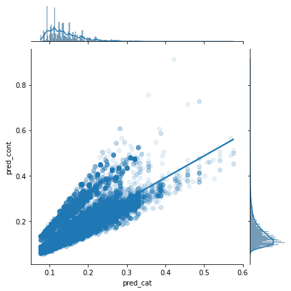

```python
sb.jointplot(data = my_data_train, x = "pred_cat", y = "pred_cont", kind = "reg", joint_kws = {"scatter_kws":dict(alpha=0.1)});
```

### Testons le modèle sur le Test set:

Ajout de la nouvele classe créée pour la variable Agecar:

```python
agecar1_map = {'0-1': 'A.0-1',
                   '2-5': 'B.2-5',
                   '6-10': 'C.>6',
                   '>10': 'C.>6'}

my_data_test['agecar1'] = my_data_test['agecar'].map(agecar1_map)
```

```python
agecar1_map = {'0-1': 'A.0-1',
                   '2-5': 'B.2-5',
                   '6-10': 'C.>6',
                   '>10': 'C.>6'}

my_data['agecar1'] = my_data['agecar'].map(agecar1_map)
```

```python
my_data_test.columns
```

```
Index(['AGEPH', 'CODPOSS', 'duree', 'lnexpo', 'nbrtotan', 'chargtot', 'agecar',
       'sexp', 'fuelc', 'split', 'usec', 'fleetc', 'sportc', 'coverp',
       'powerc', 'avg', 'AGEPH2', 'split1', 'powerc1', 'CODPOSS1', 'AGEPH3',
       'nbrtotc', 'agecar1'],
      dtype='object')
```

```python
freq_glm_tot_ref_int3_test = smf.glm('nbrtotc ~ C(coverp,Treatment(reference="MTPL"))+C(powerc1,Treatment(reference="A.<66")) + C(AGEPH3, Treatment(reference="C.31-50")):C(sexp, Treatment(reference="Male"))+ C(agecar1, Treatment(reference="C.>6"))  + C(fuelc, Treatment(reference="Gasoil")) + C(split1, Treatment(reference="A.Once")) ' , data = my_data_test, exposure = my_data_test.duree,  family = sm.families.Poisson(link=sm.families.links.log())).fit()

print(freq_glm_tot_ref_int3_test.summary())
```

```
                 Generalized Linear Model Regression Results
==============================================================================
Dep. Variable:                nbrtotc   No. Observations:                32732
Model:                            GLM   Df Residuals:                    32715
Model Family:                 Poisson   Df Model:                           16
Link Function:                    log   Scale:                          1.0000
Method:                          IRLS   Log-Likelihood:                -12614.
Date:                Wed, 12 Jan 2022   Deviance:                       17663.
Time:                        19:58:52   Pearson chi2:                 3.96e+04
No. Iterations:                     6
Covariance Type:            nonrobust
=====================================================================================================================================================================
                                                                                                        coef    std err          z      P>|z|      [0.025      0.975]
---------------------------------------------------------------------------------------------------------------------------------------------------------------------
Intercept                                                                                            -1.9672      0.043    -45.954      0.000      -2.051      -1.883
C(coverp, Treatment(reference="MTPL"))[T.MTPL+]                                                      -0.1633      0.038     -4.274      0.000      -0.238      -0.088
C(coverp, Treatment(reference="MTPL"))[T.MTPL+++]                                                    -0.1900      0.055     -3.446      0.001      -0.298      -0.082
C(powerc1, Treatment(reference="A.<66"))[T.B.>66]                                                     0.1062      0.037      2.887      0.004       0.034       0.178
C(agecar1, Treatment(reference="C.>6"))[T.A.0-1]                                                      0.1216      0.076      1.597      0.110      -0.028       0.271
C(agecar1, Treatment(reference="C.>6"))[T.B.2-5]                                                     -0.0661      0.038     -1.725      0.085      -0.141       0.009
C(fuelc, Treatment(reference="Gasoil"))[T.Petrol]                                                    -0.2071      0.034     -6.105      0.000      -0.274      -0.141
C(split1, Treatment(reference="A.Once"))[T.B.Twice]                                                   0.1484      0.038      3.932      0.000       0.074       0.222
C(split1, Treatment(reference="A.Once"))[T.C.Trice]                                                   0.3491      0.055      6.325      0.000       0.241       0.457
C(split1, Treatment(reference="A.Once"))[T.D.Monthly]                                                 0.4336      0.047      9.227      0.000       0.341       0.526
C(sexp, Treatment(reference="Male"))[T.Female]                                                        0.1314      0.050      2.615      0.009       0.033       0.230
C(AGEPH3, Treatment(reference="C.31-50"))[T.A.18-20]:C(sexp, Treatment(reference="Male"))[Female]     0.7896      0.305      2.592      0.010       0.193       1.387
C(AGEPH3, Treatment(reference="C.31-50"))[T.B.21-30]:C(sexp, Treatment(reference="Male"))[Female]     0.2585      0.072      3.569      0.000       0.117       0.400
C(AGEPH3, Treatment(reference="C.31-50"))[T.D.>50]:C(sexp, Treatment(reference="Male"))[Female]      -0.1368      0.074     -1.844      0.065      -0.282       0.009
C(AGEPH3, Treatment(reference="C.31-50"))[T.A.18-20]:C(sexp, Treatment(reference="Male"))[Male]       0.7103      0.226      3.146      0.002       0.268       1.153
C(AGEPH3, Treatment(reference="C.31-50"))[T.B.21-30]:C(sexp, Treatment(reference="Male"))[Male]       0.4439      0.051      8.759      0.000       0.345       0.543
C(AGEPH3, Treatment(reference="C.31-50"))[T.D.>50]:C(sexp, Treatment(reference="Male"))[Male]        -0.1471      0.043     -3.446      0.001      -0.231      -0.063
=====================================================================================================================================================================
```

```python
freq_glm_tot_ref_int3_total = smf.glm('nbrtotc ~ C(coverp,Treatment(reference="MTPL"))+C(powerc1,Treatment(reference="A.<66")) + C(AGEPH3, Treatment(reference="C.31-50")):C(sexp, Treatment(reference="Male"))+ C(agecar1, Treatment(reference="C.>6"))  + C(fuelc, Treatment(reference="Gasoil")) + C(split1, Treatment(reference="A.Once")) ' , data = my_data, exposure = my_data.duree,  family = sm.families.Poisson(link=sm.families.links.log())).fit()

print(freq_glm_tot_ref_int3_total.summary())
```

```
                 Generalized Linear Model Regression Results
==============================================================================
Dep. Variable:                nbrtotc   No. Observations:               163657
Model:                            GLM   Df Residuals:                   163640
Model Family:                 Poisson   Df Model:                           16
Link Function:                    log   Scale:                          1.0000
Method:                          IRLS   Log-Likelihood:                -63025.
Date:                Wed, 12 Jan 2022   Deviance:                       88216.
Time:                        20:01:00   Pearson chi2:                 1.93e+05
No. Iterations:                     6
Covariance Type:            nonrobust
=====================================================================================================================================================================
                                                                                                        coef    std err          z      P>|z|      [0.025      0.975]
---------------------------------------------------------------------------------------------------------------------------------------------------------------------
Intercept                                                                                            -1.9986      0.019   -103.735      0.000      -2.036      -1.961
C(coverp, Treatment(reference="MTPL"))[T.MTPL+]                                                      -0.1197      0.017     -7.082      0.000      -0.153      -0.087
C(coverp, Treatment(reference="MTPL"))[T.MTPL+++]                                                    -0.1396      0.024     -5.735      0.000      -0.187      -0.092
C(powerc1, Treatment(reference="A.<66"))[T.B.>66]                                                     0.1033      0.016      6.309      0.000       0.071       0.135
C(agecar1, Treatment(reference="C.>6"))[T.A.0-1]                                                      0.1679      0.033      5.065      0.000       0.103       0.233
C(agecar1, Treatment(reference="C.>6"))[T.B.2-5]                                                     -0.0727      0.017     -4.228      0.000      -0.106      -0.039
C(fuelc, Treatment(reference="Gasoil"))[T.Petrol]                                                    -0.1743      0.015    -11.429      0.000      -0.204      -0.144
C(split1, Treatment(reference="A.Once"))[T.B.Twice]                                                   0.1763      0.017     10.479      0.000       0.143       0.209
C(split1, Treatment(reference="A.Once"))[T.C.Trice]                                                   0.3998      0.024     16.466      0.000       0.352       0.447
C(split1, Treatment(reference="A.Once"))[T.D.Monthly]                                                 0.3960      0.021     18.597      0.000       0.354       0.438
C(sexp, Treatment(reference="Male"))[T.Female]                                                        0.1075      0.022      4.799      0.000       0.064       0.151
C(AGEPH3, Treatment(reference="C.31-50"))[T.A.18-20]:C(sexp, Treatment(reference="Male"))[Female]     0.6618      0.147      4.497      0.000       0.373       0.950
C(AGEPH3, Treatment(reference="C.31-50"))[T.B.21-30]:C(sexp, Treatment(reference="Male"))[Female]     0.2064      0.033      6.228      0.000       0.141       0.271
C(AGEPH3, Treatment(reference="C.31-50"))[T.D.>50]:C(sexp, Treatment(reference="Male"))[Female]      -0.1542      0.033     -4.638      0.000      -0.219      -0.089
C(AGEPH3, Treatment(reference="C.31-50"))[T.A.18-20]:C(sexp, Treatment(reference="Male"))[Male]       0.9634      0.101      9.497      0.000       0.765       1.162
C(AGEPH3, Treatment(reference="C.31-50"))[T.B.21-30]:C(sexp, Treatment(reference="Male"))[Male]       0.4751      0.022     21.399      0.000       0.432       0.519
C(AGEPH3, Treatment(reference="C.31-50"))[T.D.>50]:C(sexp, Treatment(reference="Male"))[Male]        -0.1787      0.019     -9.330      0.000      -0.216      -0.141
=====================================================================================================================================================================
```

# GLM Severity

Premier modèle avec toutes la variables:  
(en fixant déjà les classes de réference)

```python
sev_glm1 = smf.glm('avg ~  C(coverp,Treatment(reference="MTPL"))+C(powerc1,Treatment(reference="A.<66")) + C(AGEPH3, Treatment(reference="C.31-50")) + C(sexp, Treatment(reference="Male"))+ C(agecar1, Treatment(reference="C.>6"))  + C(fuelc, Treatment(reference="Gasoil")) + C(split1, Treatment(reference="A.Once")) + C(usec, Treatment(reference="Private")) + C(fleetc, Treatment(reference="No")) + C(sportc, Treatment(reference = "No")) + C(CODPOSS1, Treatment(reference = "H.Hainaut"))'    , data = my_data_train, family = sm.families.Gamma(link=sm.families.links.log())).fit()
print(sev_glm1.summary())
```

```
                 Generalized Linear Model Regression Results
==============================================================================
Dep. Variable:                    avg   No. Observations:                14676
Model:                            GLM   Df Residuals:                    14649
Model Family:                   Gamma   Df Model:                           26
Link Function:                    log   Scale:                          23.594
Method:                          IRLS   Log-Likelihood:            -1.3915e+05
Date:                Wed, 12 Jan 2022   Deviance:                       35163.
Time:                        20:11:18   Pearson chi2:                 3.46e+05
No. Iterations:                    27
Covariance Type:            nonrobust
==========================================================================================================================================
                                                                             coef    std err          z      P>|z|      [0.025      0.975]
------------------------------------------------------------------------------------------------------------------------------------------
Intercept                                                                  7.3830      0.136     54.227      0.000       7.116       7.650
C(coverp, Treatment(reference="MTPL"))[T.MTPL+]                           -0.1089      0.100     -1.093      0.275      -0.304       0.086
C(coverp, Treatment(reference="MTPL"))[T.MTPL+++]                          0.2537      0.140      1.815      0.070      -0.020       0.528
C(powerc1, Treatment(reference="A.<66"))[T.B.>66]                          0.0822      0.095      0.864      0.387      -0.104       0.269
C(AGEPH3, Treatment(reference="C.31-50"))[T.A.18-20]                       0.0060      0.497      0.012      0.990      -0.967       0.979
C(AGEPH3, Treatment(reference="C.31-50"))[T.B.21-30]                       0.2397      0.109      2.207      0.027       0.027       0.453
C(AGEPH3, Treatment(reference="C.31-50"))[T.D.>50]                        -0.1545      0.095     -1.627      0.104      -0.341       0.032
C(sexp, Treatment(reference="Male"))[T.Female]                             0.0484      0.092      0.527      0.598      -0.132       0.229
C(agecar1, Treatment(reference="C.>6"))[T.A.0-1]                          -0.0314      0.189     -0.166      0.868      -0.402       0.339
C(agecar1, Treatment(reference="C.>6"))[T.B.2-5]                          -0.1226      0.098     -1.249      0.212      -0.315       0.070
C(fuelc, Treatment(reference="Gasoil"))[T.Petrol]                          0.1122      0.088      1.276      0.202      -0.060       0.284
C(split1, Treatment(reference="A.Once"))[T.B.Twice]                       -0.2649      0.100     -2.643      0.008      -0.461      -0.068
C(split1, Treatment(reference="A.Once"))[T.C.Trice]                       -0.1254      0.144     -0.871      0.384      -0.407       0.157
C(split1, Treatment(reference="A.Once"))[T.D.Monthly]                     -0.1581      0.126     -1.252      0.211      -0.406       0.089
C(usec, Treatment(reference="Private"))[T.Professional]                   -0.0483      0.191     -0.253      0.800      -0.422       0.325
C(fleetc, Treatment(reference="No"))[T.Yes]                               -0.1240      0.246     -0.504      0.614      -0.606       0.358
C(sportc, Treatment(reference="No"))[T.Yes]                               -0.0140      0.393     -0.036      0.972      -0.784       0.756
C(CODPOSS1, Treatment(reference="H.Hainaut"))[T.A.Bruxelles-Capitale]     -0.2673      0.163     -1.637      0.102      -0.588       0.053
C(CODPOSS1, Treatment(reference="H.Hainaut"))[T.B.Brabant wallon]          0.0559      0.210      0.266      0.790      -0.356       0.468
C(CODPOSS1, Treatment(reference="H.Hainaut"))[T.C.Brabant flamand]        -0.1504      0.169     -0.888      0.375      -0.482       0.182
C(CODPOSS1, Treatment(reference="H.Hainaut"))[T.D.Anvers]                 -0.0136      0.149     -0.091      0.928      -0.306       0.279
C(CODPOSS1, Treatment(reference="H.Hainaut"))[T.E.Limbourg]                0.2113      0.207      1.022      0.307      -0.194       0.617
C(CODPOSS1, Treatment(reference="H.Hainaut"))[T.F.Liège]                  -0.1409      0.139     -1.012      0.312      -0.414       0.132
C(CODPOSS1, Treatment(reference="H.Hainaut"))[T.G.Namur]                   0.2764      0.204      1.354      0.176      -0.124       0.676
C(CODPOSS1, Treatment(reference="H.Hainaut"))[T.I.Luxembourg]             -0.0804      0.307     -0.262      0.793      -0.682       0.522
C(CODPOSS1, Treatment(reference="H.Hainaut"))[T.J.Flandre-Occidentale]     0.0746      0.164      0.455      0.649      -0.247       0.396
C(CODPOSS1, Treatment(reference="H.Hainaut"))[T.K.Flandre-Orientale]       0.0255      0.154      0.166      0.868      -0.276       0.327
==========================================================================================================================================
```

Retirons la variable CODPOSS1 (=provinces) qui ne semble pas significative:

```python
sev_glm2 = smf.glm('avg ~  C(coverp,Treatment(reference="MTPL"))+C(powerc1,Treatment(reference="A.<66")) + C(AGEPH3, Treatment(reference="C.31-50")) + C(sexp, Treatment(reference="Male"))+ C(agecar1, Treatment(reference="C.>6"))  + C(fuelc, Treatment(reference="Gasoil")) + C(split1, Treatment(reference="A.Once")) + C(usec, Treatment(reference="Private")) + C(fleetc, Treatment(reference="No")) + C(sportc, Treatment(reference = "No")) '    , data = my_data_train, family = sm.families.Gamma(link=sm.families.links.log())).fit()
print(sev_glm2.summary())
```

```
                 Generalized Linear Model Regression Results
==============================================================================
Dep. Variable:                    avg   No. Observations:                14676
Model:                            GLM   Df Residuals:                    14659
Model Family:                   Gamma   Df Model:                           16
Link Function:                    log   Scale:                          25.985
Method:                          IRLS   Log-Likelihood:            -1.4035e+05
Date:                Wed, 12 Jan 2022   Deviance:                       35400.
Time:                        20:14:17   Pearson chi2:                 3.81e+05
No. Iterations:                    20
Covariance Type:            nonrobust
===========================================================================================================================
                                                              coef    std err          z      P>|z|      [0.025      0.975]
---------------------------------------------------------------------------------------------------------------------------
Intercept                                                   7.4003      0.112     66.129      0.000       7.181       7.620
C(coverp, Treatment(reference="MTPL"))[T.MTPL+]            -0.1228      0.101     -1.210      0.226      -0.322       0.076
C(coverp, Treatment(reference="MTPL"))[T.MTPL+++]           0.2235      0.145      1.538      0.124      -0.061       0.508
C(powerc1, Treatment(reference="A.<66"))[T.B.>66]           0.0969      0.100      0.973      0.330      -0.098       0.292
C(AGEPH3, Treatment(reference="C.31-50"))[T.A.18-20]        0.0276      0.520      0.053      0.958      -0.992       1.047
C(AGEPH3, Treatment(reference="C.31-50"))[T.B.21-30]        0.2334      0.113      2.070      0.038       0.012       0.454
C(AGEPH3, Treatment(reference="C.31-50"))[T.D.>50]         -0.1832      0.099     -1.843      0.065      -0.378       0.012
C(sexp, Treatment(reference="Male"))[T.Female]              0.0707      0.096      0.734      0.463      -0.118       0.259
C(agecar1, Treatment(reference="C.>6"))[T.A.0-1]           -0.0208      0.198     -0.105      0.916      -0.409       0.368
C(agecar1, Treatment(reference="C.>6"))[T.B.2-5]           -0.1094      0.103     -1.065      0.287      -0.311       0.092
C(fuelc, Treatment(reference="Gasoil"))[T.Petrol]           0.0986      0.092      1.075      0.282      -0.081       0.278
C(split1, Treatment(reference="A.Once"))[T.B.Twice]        -0.2892      0.101     -2.863      0.004      -0.487      -0.091
C(split1, Treatment(reference="A.Once"))[T.C.Trice]        -0.1487      0.147     -1.010      0.312      -0.437       0.140
C(split1, Treatment(reference="A.Once"))[T.D.Monthly]      -0.2177      0.128     -1.695      0.090      -0.470       0.034
C(usec, Treatment(reference="Private"))[T.Professional]    -0.0437      0.200     -0.219      0.827      -0.436       0.348
C(fleetc, Treatment(reference="No"))[T.Yes]                -0.1672      0.258     -0.648      0.517      -0.673       0.338
C(sportc, Treatment(reference="No"))[T.Yes]                -0.0412      0.412     -0.100      0.920      -0.849       0.766
===========================================================================================================================
```

```python
sev_glm3 = smf.glm('avg ~  C(coverp,Treatment(reference="MTPL"))+C(powerc1,Treatment(reference="A.<66")) + C(AGEPH3, Treatment(reference="C.31-50")) + C(sexp, Treatment(reference="Male"))+ C(agecar1, Treatment(reference="C.>6"))  + C(fuelc, Treatment(reference="Gasoil")) + C(split1, Treatment(reference="A.Once")) + C(fleetc, Treatment(reference="No")) + C(sportc, Treatment(reference = "No")) '    , data = my_data_train, family = sm.families.Gamma(link=sm.families.links.log())).fit()
print(sev_glm3.summary())
```

```
                 Generalized Linear Model Regression Results
==============================================================================
Dep. Variable:                    avg   No. Observations:                14676
Model:                            GLM   Df Residuals:                    14660
Model Family:                   Gamma   Df Model:                           15
Link Function:                    log   Scale:                          26.053
Method:                          IRLS   Log-Likelihood:            -1.4038e+05
Date:                Wed, 12 Jan 2022   Deviance:                       35401.
Time:                        20:17:57   Pearson chi2:                 3.82e+05
No. Iterations:                    19
Covariance Type:            nonrobust
=========================================================================================================================
                                                            coef    std err          z      P>|z|      [0.025      0.975]
-------------------------------------------------------------------------------------------------------------------------
Intercept                                                 7.3978      0.111     66.421      0.000       7.179       7.616
C(coverp, Treatment(reference="MTPL"))[T.MTPL+]          -0.1244      0.102     -1.225      0.221      -0.324       0.075
C(coverp, Treatment(reference="MTPL"))[T.MTPL+++]         0.2212      0.145      1.524      0.128      -0.063       0.506
C(powerc1, Treatment(reference="A.<66"))[T.B.>66]         0.0952      0.099      0.958      0.338      -0.099       0.290
C(AGEPH3, Treatment(reference="C.31-50"))[T.A.18-20]      0.0288      0.521      0.055      0.956      -0.992       1.050
C(AGEPH3, Treatment(reference="C.31-50"))[T.B.21-30]      0.2344      0.113      2.077      0.038       0.013       0.455
C(AGEPH3, Treatment(reference="C.31-50"))[T.D.>50]       -0.1836      0.100     -1.845      0.065      -0.379       0.011
C(sexp, Treatment(reference="Male"))[T.Female]            0.0712      0.096      0.739      0.460      -0.118       0.260
C(agecar1, Treatment(reference="C.>6"))[T.A.0-1]         -0.0187      0.198     -0.094      0.925      -0.408       0.370
C(agecar1, Treatment(reference="C.>6"))[T.B.2-5]         -0.1085      0.103     -1.055      0.291      -0.310       0.093
C(fuelc, Treatment(reference="Gasoil"))[T.Petrol]         0.1004      0.092      1.095      0.273      -0.079       0.280
C(split1, Treatment(reference="A.Once"))[T.B.Twice]      -0.2882      0.101     -2.853      0.004      -0.486      -0.090
C(split1, Treatment(reference="A.Once"))[T.C.Trice]      -0.1489      0.147     -1.011      0.312      -0.438       0.140
C(split1, Treatment(reference="A.Once"))[T.D.Monthly]    -0.2177      0.129     -1.693      0.090      -0.470       0.034
C(fleetc, Treatment(reference="No"))[T.Yes]              -0.1774      0.257     -0.689      0.491      -0.682       0.327
C(sportc, Treatment(reference="No"))[T.Yes]              -0.0385      0.412     -0.093      0.926      -0.847       0.770
=========================================================================================================================
```